# STARmap PLUS: Control-Only Spatial Object (8 vs 13 Months)

- Show All Code
- Hide All Code
- View Source

Seurat object (counts, metadata, coordinates) for the 4 control sections, plus a hippocampus-only subset

Published

October 9, 2026

## 1 Overview

STARmap PLUS (Zeng et al., Nat Neurosci 2023; SCP1375), control mice only: 8 and 13 months, 2 sections each (35,771 cells).

1. Plot the 4 sections coloured by cell type.
2. Build a Seurat object from `expression_matrix_raw.csv`, `metadata.csv` and the per-section coordinate files.
3. Subset to the hippocampus and save both objects.

```r
library(dplyr)
library(purrr)
library(tibble)
library(ggplot2)
library(patchwork)
library(Matrix)
library(Seurat)

data_dir <- "STARmap_PLUS_data"

out_dir <- file.path("output", "07_STARmapPLUS_ControlSpatialObject")
dir.create(out_dir, recursive = TRUE, showWarnings = FALSE)
```

## 2 Spatial plot

### 2.1 Load the 4 control coordinate files

```r
spatial_files <- c(
  "8months-control-replicate_1"  = file.path(data_dir, "spatial_8months-control-replicate_1.csv"),
  "8months-control-replicate_2"  = file.path(data_dir, "spatial_8months-control-replicate_2.csv"),
  "13months-control-replicate_1" = file.path(data_dir, "spatial_13months-control-replicate_1.csv"),
  "13months-control-replicate_2" = file.path(data_dir, "spatial_13months-control-replicate_2.csv")
)

panel_order <- names(spatial_files)

read_scp_cluster_file <- function(path) {
  out <- read.csv(path, skip = 2, header = FALSE,
                   col.names = c("NAME", "X", "Y", "X_scaled", "Y_scaled",
                                 "label", "top_level_cell_type", "sub_level_cell_type"),
                   colClasses = c("character", "numeric", "numeric", "numeric", "numeric",
                                  "character", "character", "character"))
  stopifnot(is.numeric(out$X), is.numeric(out$Y))
  out
}

spatial_all <- map_dfr(spatial_files, read_scp_cluster_file) |>
  mutate(label = factor(label, levels = panel_order))

spatial_all
```

| NAME | X | Y | X_scaled | Y_scaled | label | top_level_cell_type | sub_level_cell_type |
| --- | --- | --- | --- | --- | --- | --- | --- |
| 50123 | 971 | 17 | 5587 | 5 | 8months-control-replicate_1 | DG | DG |
| 50124 | 1935 | 50 | 5298 | 15 | 8months-control-replicate_1 | Inh | Pvalb |
| 50125 | 14170 | 27 | 1627 | 8 | 8months-control-replicate_1 | Astro | Astro3 |
| 50126 | 3654 | 28 | 4782 | 8 | 8months-control-replicate_1 | CA3 | CA3-Ex |
| 50127 | 2272 | 32 | 5196 | 9 | 8months-control-replicate_1 | DG | DG |
| 50128 | 9588 | 27 | 3002 | 8 | 8months-control-replicate_1 | Endo | Endo2 |
| 50129 | 13028 | 29 | 1970 | 8 | 8months-control-replicate_1 | Oligo | Oligo1 |
| 50130 | 17677 | 30 | 575 | 9 | 8months-control-replicate_1 | Oligo | Oligo1 |
| 50131 | 15636 | 33 | 1187 | 9 | 8months-control-replicate_1 | Astro | Astro3 |
| 50132 | 15090 | 31 | 1351 | 9 | 8months-control-replicate_1 | Oligo | Oligo2 |

[output cut: 9990 more lines]

### 2.2 Cell-type palette

```r
cell_type_palette <- c(
  "Astro"  = "#1f77b4",
  "CA1"    = "#ff7f0e",
  "CA2"    = "#2ca02c",
  "CA3"    = "#d62728",
  "CTX-Ex" = "#9467bd",
  "DG"     = "#8c564b",
  "Endo"   = "#e377c2",
  "Inh"    = "#7f7f7f",
  "LHb"    = "#bcbd22",
  "Micro"  = "#17becf",
  "OPC"    = "#aec7e8",
  "Oligo"  = "#ffbb78",
  "SMC"    = "#98df8a"
)

spatial_all <- spatial_all |>
  mutate(top_level_cell_type = factor(top_level_cell_type, levels = names(cell_type_palette)))
```

### 2.3 Plot

One panel per section, y axis flipped (image coordinates). Built as 4 separate plots combined with `patchwork`, because `facet_wrap(scales = "free")` can’t be combined with `coord_fixed()`.

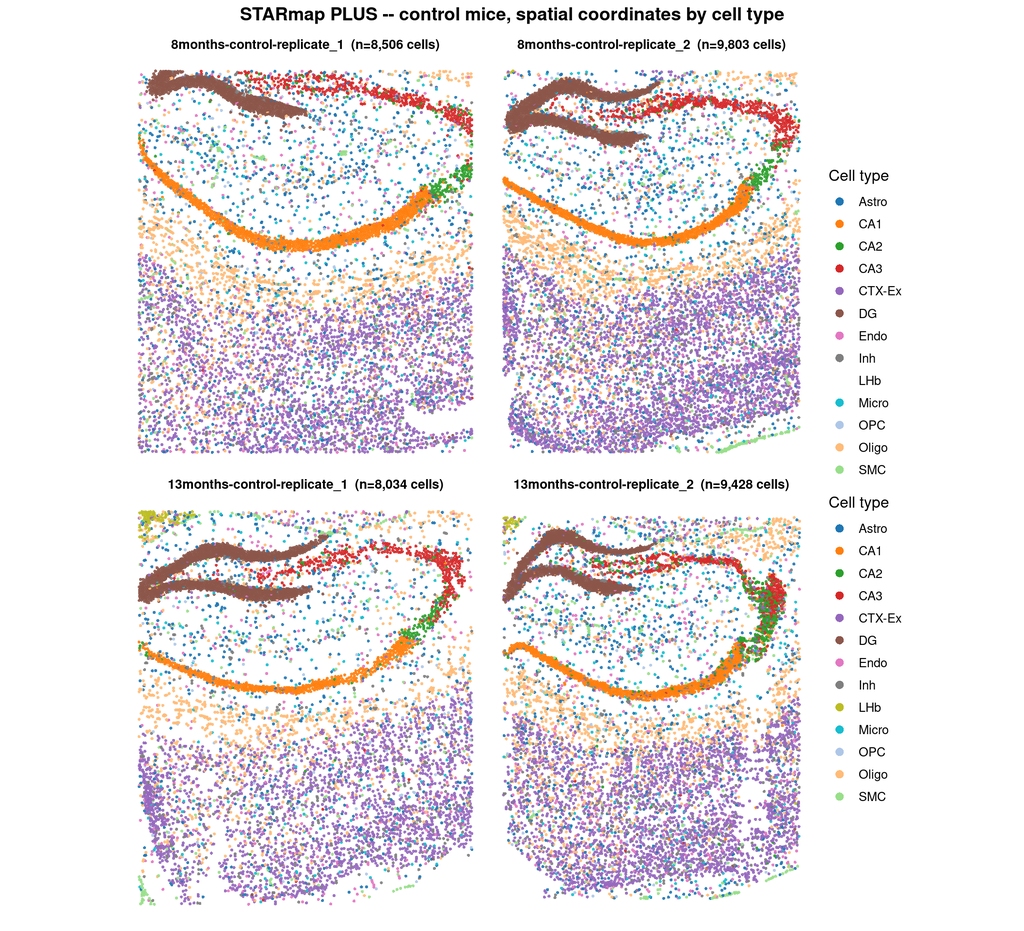

```r
panel_titles <- spatial_all |>
  count(label, name = "n_cells", .drop = FALSE) |>
  mutate(panel_title = sprintf("%s  (n=%s cells)", label, format(n_cells, big.mark = ","))) |>
  select(label, panel_title) |>
  deframe()

plot_one_sample <- function(lbl) {
  sub <- spatial_all |> filter(label == lbl)
  ggplot(sub, aes(x = X, y = Y, color = top_level_cell_type)) +
    geom_point(size = 1.1, alpha = 0.9, stroke = 0) +
    scale_color_manual(values = cell_type_palette, name = "Cell type", drop = FALSE) +
    scale_y_reverse() +
    coord_fixed() +
    guides(color = guide_legend(override.aes = list(size = 3, alpha = 1))) +
    labs(title = panel_titles[[as.character(lbl)]]) +
    theme_void(base_size = 12) +
    theme(plot.title = element_text(hjust = 0.5, size = 10, face = "bold"))
}

panel_plots <- map(panel_order, plot_one_sample)

wrap_plots(panel_plots, ncol = 2) +
  plot_layout(guides = "collect") +
  plot_annotation(
    title = "STARmap PLUS -- control mice, spatial coordinates by cell type",
    theme = theme(plot.title = element_text(hjust = 0.5, face = "bold", size = 14))
  )
```

## 3 Check the expression matrix before loading it

```r
matrix_path <- file.path(data_dir, "expression_matrix_raw.csv")

raw_lines <- readLines(matrix_path, n = 2)
cat("Line 1, first 300 characters:\n")
```

```
Line 1, first 300 characters:
```

```r
cat(substr(raw_lines[1], 1, 300), "\n\n")
```

```
GENE,1,3,4,5,6,7,8,9,10,11,13,14,15,16,17,18,19,20,21,22,23,24,25,26,27,28,29,31,32,33,35,36,37,38,40,41,43,44,45,46,47,50,51,52,53,54,55,58,59,60,62,63,64,67,68,69,70,71,72,73,74,75,77,78,79,80,82,83,84,85,86,87,88,89,90,91,93,94,96,97,99,101,104,105,106,108,109,111,112,113,114,115,117,118,119,121,
```

```r
cat("Line 2, first 300 characters:\n")
```

```
Line 2, first 300 characters:
```

```r
cat(substr(raw_lines[2], 1, 300), "\n")
```

```
A2m,0.0,0.0,0.0,0.0,0.0,0.0,0.0,0.0,0.0,0.0,0.0,0.0,0.0,0.0,0.0,0.0,0.0,0.0,1.0,0.0,0.0,0.0,0.0,0.0,0.0,0.0,0.0,0.0,0.0,0.0,0.0,0.0,0.0,0.0,0.0,0.0,0.0,0.0,0.0,0.0,0.0,0.0,0.0,0.0,0.0,0.0,0.0,0.0,0.0,0.0,0.0,0.0,0.0,0.0,0.0,1.0,0.0,0.0,0.0,0.0,0.0,0.0,0.0,0.0,0.0,0.0,0.0,0.0,0.0,0.0,0.0,0.0,0.0,0.0,
```

The matrix is genes x cells: first column `GENE`, then one column per cell named by an integer cell ID.

```r
matrix_peek <- read.csv(matrix_path, header = TRUE, nrows = 5, check.names = FALSE)
n_cols <- ncol(matrix_peek)

cat("Number of columns:", n_cols, "\n")
```

```
Number of columns: 72166
```

```r
cat("First column name (gene-ID column):", names(matrix_peek)[1], "\n")
```

```
First column name (gene-ID column): GENE
```

```r
cat("First 10 cell-ID column names:\n")
```

```
First 10 cell-ID column names:
```

```r
print(head(names(matrix_peek)[-1], 10))
```

```
 [1] "1"  "3"  "4"  "5"  "6"  "7"  "8"  "9"  "10" "11"
```

```r
cat("\nFirst 5 gene names (first data column, first 5 rows):\n")
```

```
First 5 gene names (first data column, first 5 rows):
```

```r
print(matrix_peek[[1]])
```

```
[1] "A2m"   "Aagab" "Aak1"  "Abca2" "Abca7"
```

```r
# first data row is SCP's "TYPE" row -> drop it
metadata_all <- read.csv(file.path(data_dir, "metadata.csv"))
metadata_all <- metadata_all[metadata_all$NAME != "TYPE", ]
metadata_all$NAME <- as.integer(metadata_all$NAME)
metadata_all$orig_index <- as.integer(metadata_all$orig_index)

n_cells_total   <- nrow(metadata_all)
n_cells_control <- metadata_all |> filter(label %in% panel_order) |> nrow()
cat("Total cells in metadata.csv:", n_cells_total, "\n")
```

```
Total cells in metadata.csv: 72165
```

```r
cat("Cells in the 4 control samples:", n_cells_control, "(expected 35,771)\n\n")
```

```
Cells in the 4 control samples: 35771 (expected 35,771)
```

```r
# matrix column names should all be metadata NAME values
matrix_col_ids <- names(matrix_peek)[-1]
name_hits      <- sum(matrix_col_ids %in% as.character(metadata_all$NAME))

cat("Matrix column IDs matching metadata$NAME:", name_hits, "/", length(matrix_col_ids), "\n")
```

```
Matrix column IDs matching metadata$NAME: 72165 / 72165
```

Matrix column headers match metadata’s `NAME` column (unique across all sections); `orig_index` restarts in each section and must not be used as a key. Columns are selected by position, which is only valid if the matrix columns are in the same order as the metadata rows – checked here, and the render stops if they aren’t.

```r
matrix_ids_all <- names(matrix_peek)[-1]

same_length <- length(matrix_ids_all) == nrow(metadata_all)
same_order  <- if (same_length) identical(matrix_ids_all, as.character(metadata_all$NAME)) else FALSE

cat("Data columns in expression_matrix_raw.csv:", length(matrix_ids_all), "\n")
```

```
Data columns in expression_matrix_raw.csv: 72165
```

```r
cat("Rows in metadata.csv:", nrow(metadata_all), "\n")
```

```
Rows in metadata.csv: 72165
```

```r
cat("Same length:", same_length, "\n")
```

```
Same length: TRUE
```

```r
cat("Column order matches metadata_all$NAME row-for-row:", same_order, "\n")
```

```
Column order matches metadata_all$NAME row-for-row: TRUE
```

```r
# columns are selected by position below -> must match metadata row order
stopifnot(same_order)
```

## 4 Build the control-subset count matrix

```r
# metadata rows of the 4 control sections; the same positions index the matrix columns (+1 for GENE)
control_row_positions <- which(metadata_all$label %in% panel_order)

# new unique cell IDs; remove_rownames() so column_to_rownames() works later
control_meta <- metadata_all[control_row_positions, ] |>
  tibble::remove_rownames() |>
  mutate(cell_id = paste0("Cell_", dplyr::row_number()))

stopifnot(nrow(control_meta) == 35771)          # sanity check against the known control cell count
stopifnot(!anyDuplicated(control_meta$cell_id))  # must be unique by construction

expr_df <- read.csv(matrix_path, header = TRUE, check.names = FALSE)
gene_names <- expr_df[[1]]

expr_mat <- as.matrix(expr_df[, control_row_positions + 1])
rownames(expr_mat) <- gene_names
colnames(expr_mat) <- control_meta$cell_id

counts_sparse <- Matrix::Matrix(expr_mat, sparse = TRUE)
rm(expr_df, expr_mat); gc()
```

```
           used  (Mb) gc trigger   (Mb)  max used   (Mb)
Ncells  4088451 218.4    7686581  410.6   7686581  410.6
Vcells 19175645 146.3  416809922 3180.1 434110335 3312.0
```

```r
saveRDS(counts_sparse, file.path(out_dir, "starmap_plus_control_counts.rds"))

cat("Built control-subset count matrix:", nrow(counts_sparse), "genes x", ncol(counts_sparse), "cells\n")
```

```
Built control-subset count matrix: 2766 genes x 35771 cells
```

## 5 Assemble the Seurat object

Coordinates are stored as a 2-D `spatial` reduction (no Visium-style image slot), so `DimPlot(obj, reduction = "spatial")` works.

```r
meta_for_seurat <- control_meta |>
  column_to_rownames("cell_id")

starmap_obj <- CreateSeuratObject(
  counts    = counts_sparse,
  meta.data = meta_for_seurat,
  project   = "STARmapPLUS_control"
)

# coordinate files only have NAME -> map to cell_id via the (label, NAME) key
name_to_cell_id <- control_meta |>
  transmute(join_key = paste(as.character(label), NAME, sep = "___"), cell_id)

coords_for_seurat <- spatial_all |>
  mutate(join_key = paste(as.character(label), NAME, sep = "___")) |>
  left_join(name_to_cell_id, by = "join_key") |>
  filter(!is.na(cell_id), cell_id %in% colnames(starmap_obj)) |>
  distinct(cell_id, .keep_all = TRUE) |>
  arrange(match(cell_id, colnames(starmap_obj))) |>
  select(cell_id, X, Y)

cat("coords_for_seurat rows:", nrow(coords_for_seurat), " | ncol(starmap_obj):", ncol(starmap_obj), "\n")
```

```
coords_for_seurat rows: 35771  | ncol(starmap_obj): 35771
```

```r
cat("\ncontrol_meta rows per label:\n")
```

```
control_meta rows per label:
```

```r
print(table(control_meta$label))
```

```
13months-control-replicate_1 13months-control-replicate_2
                        8034                         9428
 8months-control-replicate_1  8months-control-replicate_2
                        8506                         9803
```

```r
cat("\nspatial_all rows per label:\n")
```

```
spatial_all rows per label:
```

```r
print(table(spatial_all$label))
```

```
 8months-control-replicate_1  8months-control-replicate_2
                        8506                         9803
13months-control-replicate_1 13months-control-replicate_2
                        8034                         9428
```

```r
missing_cell_ids <- setdiff(colnames(starmap_obj), coords_for_seurat$cell_id)
cat("\nCells in starmap_obj with NO matched spatial coordinate:", length(missing_cell_ids), "\n")
```

```
Cells in starmap_obj with NO matched spatial coordinate: 0
```

```r
if (length(missing_cell_ids) > 0) {
  missing_preview <- control_meta[control_meta$cell_id %in% head(missing_cell_ids, 10),
                                   c("cell_id", "label", "NAME")]
  cat("A sample of unmatched cells (check these NAME/label values against spatial_all by eye):\n")
  print(missing_preview)
}

stopifnot(nrow(coords_for_seurat) == ncol(starmap_obj))

spatial_emb <- as.matrix(coords_for_seurat |> select(X, Y))
rownames(spatial_emb) <- coords_for_seurat$cell_id
colnames(spatial_emb) <- c("spatial_1", "spatial_2")

starmap_obj[["spatial"]] <- CreateDimReducObject(
  embeddings = spatial_emb,
  key = "spatial_",
  assay = DefaultAssay(starmap_obj)
)

saveRDS(starmap_obj, file.path(out_dir, "starmap_plus_control_seurat.rds"))

starmap_obj
```

```
An object of class Seurat
2766 features across 35771 samples within 1 assay
Active assay: RNA (2766 features, 0 variable features)
 1 layer present: counts
 1 dimensional reduction calculated: spatial
```

## 6 Verify: re-plot from the Seurat object

Same plot as above, rebuilt only from `starmap_obj`. If counts, metadata and coordinates are aligned, it looks identical.

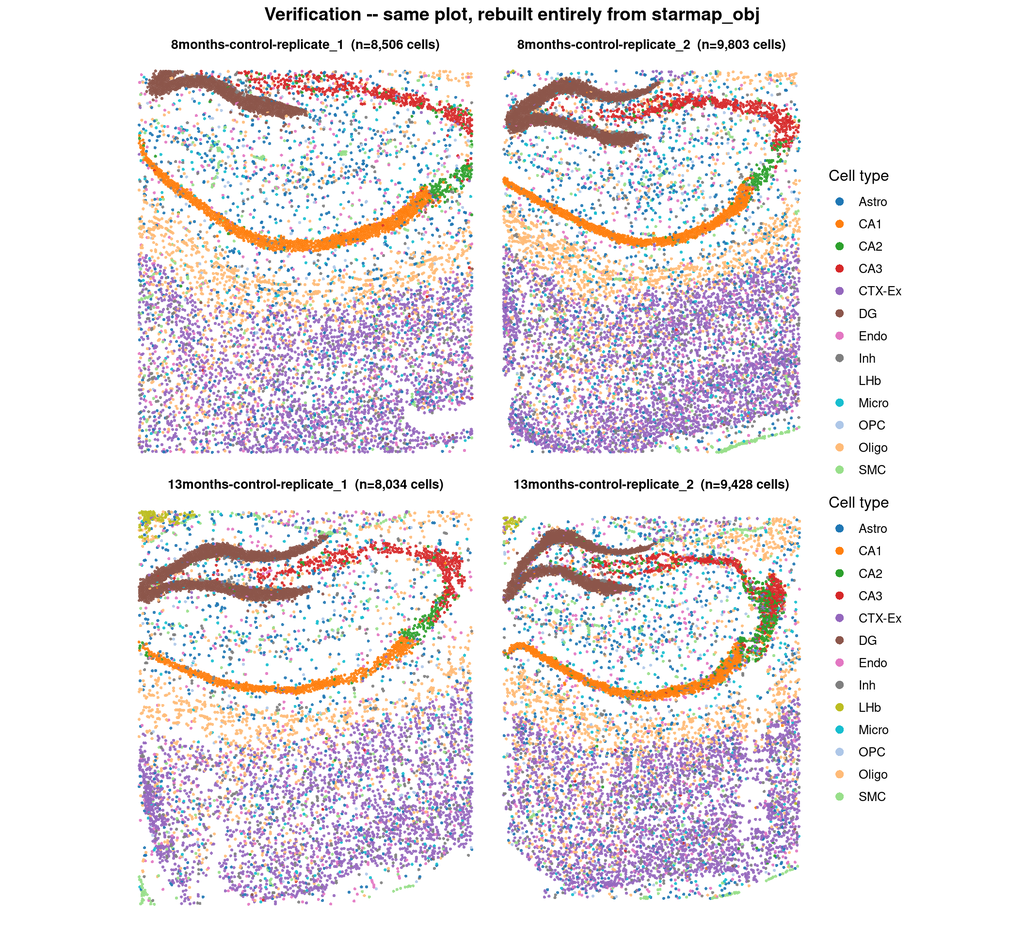

```r
verify_coords <- as.data.frame(Embeddings(starmap_obj, "spatial"))
verify_coords$cell_id <- rownames(verify_coords)

verify_meta <- starmap_obj@meta.data
verify_meta$cell_id <- rownames(verify_meta)

verify_df <- verify_coords |>
  left_join(verify_meta |> select(cell_id, label, top_level_cell_type), by = "cell_id") |>
  mutate(
    label = factor(label, levels = panel_order),
    top_level_cell_type = factor(top_level_cell_type, levels = names(cell_type_palette))
  )

stopifnot(nrow(verify_df) == ncol(starmap_obj))  # every cell got a coordinate + cell type back

verify_panel_titles <- verify_df |>
  count(label, name = "n_cells", .drop = FALSE) |>
  mutate(panel_title = sprintf("%s  (n=%s cells)", label, format(n_cells, big.mark = ","))) |>
  select(label, panel_title) |>
  deframe()

plot_one_sample_verify <- function(lbl) {
  sub <- verify_df |> filter(label == lbl)
  ggplot(sub, aes(x = spatial_1, y = spatial_2, color = top_level_cell_type)) +
    geom_point(size = 1.1, alpha = 0.9, stroke = 0) +
    scale_color_manual(values = cell_type_palette, name = "Cell type", drop = FALSE) +
    scale_y_reverse() +
    coord_fixed() +
    guides(color = guide_legend(override.aes = list(size = 3, alpha = 1))) +
    labs(title = verify_panel_titles[[as.character(lbl)]]) +
    theme_void(base_size = 12) +
    theme(plot.title = element_text(hjust = 0.5, size = 10, face = "bold"))
}

verify_plots <- map(panel_order, plot_one_sample_verify)

wrap_plots(verify_plots, ncol = 2) +
  plot_layout(guides = "collect") +
  plot_annotation(
    title = "Verification -- same plot, rebuilt entirely from starmap_obj",
    theme = theme(plot.title = element_text(hjust = 0.5, face = "bold", size = 14))
  )
```

## 7 Restrict to hippocampus

`metadata.csv`’s `region` column is used directly.

```r
cat("Cells per region (all 4 samples combined):\n")
```

```
Cells per region (all 4 samples combined):
```

```r
print(table(starmap_obj$region))
```

```
         Alveus Corpus Callosum          Cortex     Hippocampus
            534            2215           16744           16278
```

```r
cat("\nCells per region_merged:\n")
```

```
Cells per region_merged:
```

```r
print(table(starmap_obj$region_merged))
```

```
Corpus Callosum          Cortex     Hippocampus
           2215           16744           16812
```

```r
cat("\nCells per region x sample:\n")
```

```
Cells per region x sample:
```

```r
print(table(starmap_obj$region, starmap_obj$label))
```

```
                  13months-control-replicate_1 13months-control-replicate_2
  Alveus                                    67                          146
  Corpus Callosum                          526                          357
  Cortex                                  3540                         4323
  Hippocampus                             3901                         4602

                  8months-control-replicate_1 8months-control-replicate_2
  Alveus                                  144                         177
  Corpus Callosum                         820                         512
  Cortex                                 3842                        5039
  Hippocampus                            3700                        4075
```

Subset to `region == "Hippocampus"`; the full object is saved separately.

```r
starmap_hpc <- subset(starmap_obj, subset = region == "Hippocampus")

cat("Hippocampus-only:", ncol(starmap_hpc), "cells (from", ncol(starmap_obj), "total)\n")
```

```
Hippocampus-only: 16278 cells (from 35771 total)
```

```r
cat("\nPer-sample counts, hippocampus only:\n")
```

```
Per-sample counts, hippocampus only:
```

```r
print(table(starmap_hpc$label))
```

```
13months-control-replicate_1 13months-control-replicate_2
                        3901                         4602
 8months-control-replicate_1  8months-control-replicate_2
                        3700                         4075
```

```r
saveRDS(starmap_hpc, file.path(out_dir, "starmap_plus_control_seurat_hippocampus.rds"))
```

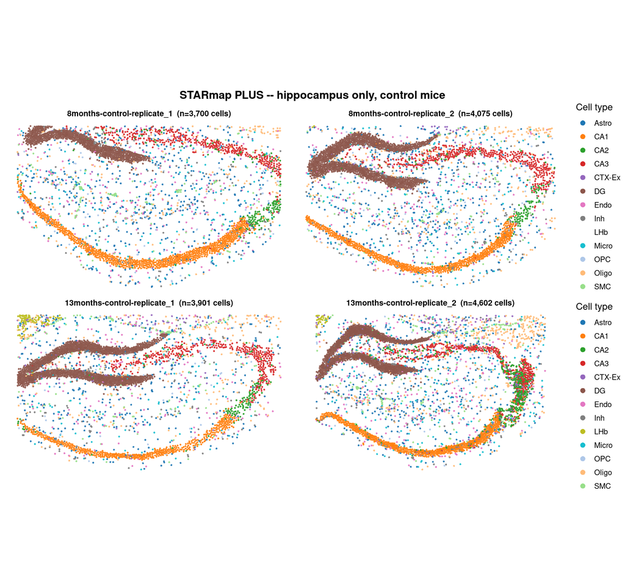

```r
hpc_coords <- as.data.frame(Embeddings(starmap_hpc, "spatial"))
hpc_coords$cell_id <- rownames(hpc_coords)

hpc_meta <- starmap_hpc@meta.data
hpc_meta$cell_id <- rownames(hpc_meta)

hpc_df <- hpc_coords |>
  left_join(hpc_meta |> select(cell_id, label, top_level_cell_type), by = "cell_id") |>
  mutate(
    label = factor(label, levels = panel_order),
    top_level_cell_type = factor(top_level_cell_type, levels = names(cell_type_palette))
  )

hpc_panel_titles <- hpc_df |>
  count(label, name = "n_cells", .drop = FALSE) |>
  mutate(panel_title = sprintf("%s  (n=%s cells)", label, format(n_cells, big.mark = ","))) |>
  select(label, panel_title) |>
  deframe()

plot_one_sample_hpc <- function(lbl) {
  sub <- hpc_df |> filter(label == lbl)
  ggplot(sub, aes(x = spatial_1, y = spatial_2, color = top_level_cell_type)) +
    geom_point(size = 1.1, alpha = 0.9, stroke = 0) +
    scale_color_manual(values = cell_type_palette, name = "Cell type", drop = FALSE) +
    scale_y_reverse() +
    coord_fixed() +
    guides(color = guide_legend(override.aes = list(size = 3, alpha = 1))) +
    labs(title = hpc_panel_titles[[as.character(lbl)]]) +
    theme_void(base_size = 12) +
    theme(plot.title = element_text(hjust = 0.5, size = 10, face = "bold"))
}

hpc_plots <- map(panel_order, plot_one_sample_hpc)

wrap_plots(hpc_plots, ncol = 2) +
  plot_layout(guides = "collect") +
  plot_annotation(
    title = "STARmap PLUS -- hippocampus only, control mice",
    theme = theme(plot.title = element_text(hjust = 0.5, face = "bold", size = 14))
  )
```

## 8 Highlight selected cell types

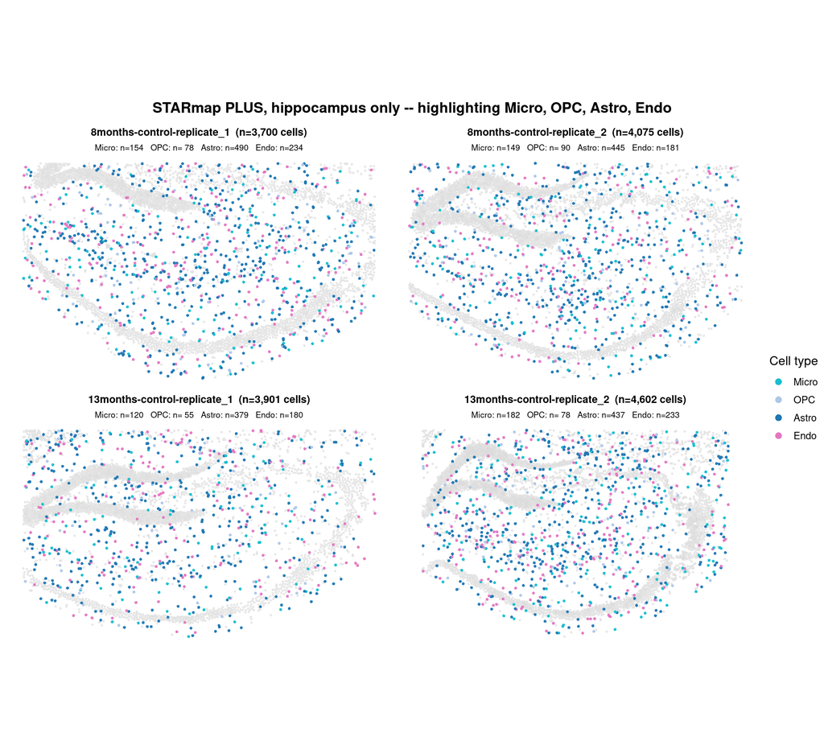

```r
highlight_types <- c("Micro", "OPC", "Astro", "Endo")

stopifnot(all(highlight_types %in% names(cell_type_palette)))

hl_coords <- as.data.frame(Embeddings(starmap_hpc, "spatial"))
hl_coords$cell_id <- rownames(hl_coords)

hl_meta <- starmap_hpc@meta.data
hl_meta$cell_id <- rownames(hl_meta)

hl_df <- hl_coords |>
  left_join(hl_meta |> select(cell_id, label, top_level_cell_type), by = "cell_id") |>
  mutate(label = factor(label, levels = panel_order))

hl_panel_titles <- hl_df |>
  count(label, name = "n_cells", .drop = FALSE) |>
  mutate(panel_title = sprintf("%s  (n=%s cells)", label, format(n_cells, big.mark = ","))) |>
  select(label, panel_title) |>
  deframe()

plot_one_sample_highlight <- function(lbl) {
  sub        <- hl_df |> filter(label == lbl)
  background <- sub |> filter(!top_level_cell_type %in% highlight_types)
  foreground <- sub |>
    filter(top_level_cell_type %in% highlight_types) |>
    mutate(top_level_cell_type = factor(top_level_cell_type, levels = highlight_types))

  per_type_n <- foreground |> count(top_level_cell_type, name = "n", .drop = FALSE)
  subtitle_txt <- paste(sprintf("%s: n=%s", per_type_n$top_level_cell_type, format(per_type_n$n, big.mark = ",")),
                         collapse = "   ")

  ggplot() +
    geom_point(data = background, aes(x = spatial_1, y = spatial_2),
               color = "grey85", size = 1.1, alpha = 0.6, stroke = 0) +
    geom_point(data = foreground, aes(x = spatial_1, y = spatial_2, color = top_level_cell_type),
               size = 1.3, alpha = 0.95, stroke = 0) +
    scale_color_manual(values = cell_type_palette[highlight_types], name = "Cell type", drop = FALSE) +
    scale_y_reverse() +
    coord_fixed() +
    guides(color = guide_legend(override.aes = list(size = 3, alpha = 1))) +
    labs(title = hl_panel_titles[[as.character(lbl)]], subtitle = subtitle_txt) +
    theme_void(base_size = 12) +
    theme(
      plot.title = element_text(hjust = 0.5, size = 10, face = "bold"),
      plot.subtitle = element_text(hjust = 0.5, size = 8)
    )
}

highlight_plots <- map(panel_order, plot_one_sample_highlight)

wrap_plots(highlight_plots, ncol = 2) +
  plot_layout(guides = "collect") +
  plot_annotation(
    title = paste("STARmap PLUS, hippocampus only -- highlighting", paste(highlight_types, collapse = ", ")),
    theme = theme(plot.title = element_text(hjust = 0.5, face = "bold", size = 14))
  )
```

## 9 Notes

- Cell IDs are new sequential `Cell_1 … Cell_n`; original `NAME`, `orig_index` and `label` are kept as metadata.
- `starmap_hpc` contains `region == "Hippocampus"` only.
- Saved: `starmap_plus_control_seurat.rds` (all regions) and `starmap_plus_control_seurat_hippocampus.rds`.